# Machine Learning Prediction Project

Paul Phan

August 16, 2017

# Executive Summary

The goal of this project is to predict the manner (classe variable) in which the 6 participants did the exercise.

This report will first load the training and test data set into two separate data frames and then cleanse the data by removing any columns containing NAs that are not relevant or useful for prediction. Once the datasets are cleanse it will perform feature selection to ensure the most relevant variables are used for modelling.

Prior to model selection the training dataset will be furthur partitioned into 2 parts with the 1st part containing 70% of the observations used for model selection and the 2nd part containing 30% of the observations reserved for out-of-sample error validation. Finally when a model is selected and tested the report will predict on the 20 test cases in the testing dataset.

# Load Data Section

Loading training and testing data:

```
1. training = 19622 observations and 160 variables
2. testing = 20 observations and 160 variables
```

```r
setwd("~/Learning/Coursera/08 Machine Learning/Week 4/Course Project")

    if(!dir.exists("data")){
      dir.create("data")
    }

    #*** Training Data ***
    file_name<-"./Data/pml-training.csv"
    if(!file.exists("./Data/pml-training.csv")){#Download training data
      fileUrl<-"https://d396qusza40orc.cloudfront.net/predmachlearn/pml-training.csv"
      download.file(fileUrl,file_name)
    }
    if(!exists("training")){#Load training csv file into dataframe and replace null values with NA
      training<- read.csv(file_name, na.strings=c("NA",""), header=TRUE)
    }

    #*** Testing Data ***
    file_name<-"./Data/pml-testing.csv"
    if(!file.exists(file_name)){#Download testing data
      fileUrl<-"https://d396qusza40orc.cloudfront.net/predmachlearn/pml-testing.csv"
      download.file(fileUrl,file_name)
    }
    if(!exists("testing")){#Load testing csv file into dataframe and replace null values with NA
      testing<- read.csv(file_name, na.strings=c("NA",""), header=TRUE)
    }
```

# Clean Data Section

Cleaning training and testing data:

```
1. training = 19622 observations and 60 variables (100 variables containing NAs removed)
2. testing = 20 observations and 60 variables (100 variables containing NAs removed)
```

```r
#Clean training by removing all columns containing at least one NA value (100 variables removed)
training_nona<-training[,colSums(is.na(training))==0]

#Clean testing by removing all columns containing at least one NA value
testing_nona<-testing[,colSums(is.na(testing))==0]
```

# Feature Selection Section

Selecting variables for the model:

```
1. removed first 7 variables from the traing data set as they are time and factor variables not relevant for the model
2. removed 36 less relevant variables for better prediction
```

```r
#removing 5 not relevant variables and 36 less relevant variables
training_nona<-training_nona[,-c(1:7,12:20,25:33,38:46,51:59)]
#View(training_nona)
testing_nona<-testing_nona[,-c(1:7,12:20,25:33,38:46,51:59)]
```

# Data Slicing Section

Spliting the cleansed training data into a training set and a validation set for better algorithm performance.

```r
#Partitioning cleansed training data into training set (70%) and validation set (30%)
training_sample<-createDataPartition(y=training_nona$classe,p=0.7,list=FALSE)
training_set<-training_nona[training_sample, ]
validation_set<-training_nona[-training_sample, ]

#Further slicing our training_set for use in model selection and in-sample error
folds<-createFolds(y=training_set$classe,k=20,list=TRUE,returnTrain=FALSE)
training_1<-training_set[folds$Fold01,]
training_10<-training_set[folds$Fold10,]
#View(training_1)
```

# Model Selection

Decided to use the top performing algorithms random forest and gradient boosting for model selections since their predictions are often very accurate (ref: week 3 slide 10 of 10)

```
Result:
    1. Random forest = 82%
    2. Gradient boosting = 77%

Selection:
    1. Random forest selected since it had the higer accuracy performance at 82%
```

```r
set.seed(1122)
mod_sel_rf<-train(classe~.,data=training_1,method='rf',prox=TRUE)
mod_sel_gbm<-train(classe~.,data=training_1,method="gbm",verbose=FALSE)
#save(mod_sel_rf, file='./mod_sel_rf.RData')
print(mod_sel_rf$results)
```

```
##   mtry  Accuracy     Kappa AccuracySD    KappaSD
## 1    2 0.8162542 0.7673534 0.02309045 0.02956547
## 2    9 0.8027673 0.7503758 0.02464048 0.03177911
## 3   16 0.7905262 0.7349418 0.02679001 0.03426514
```

```r
print(mod_sel_gbm$results)
```

```
##   shrinkage interaction.depth n.minobsinnode n.trees  Accuracy     Kappa
## 1       0.1                 1             10      50 0.6332575 0.5352588
## 4       0.1                 2             10      50 0.6996685 0.6194910
## 7       0.1                 3             10      50 0.7400695 0.6704098
## 2       0.1                 1             10     100 0.6690859 0.5805441
## 5       0.1                 2             10     100 0.7384562 0.6684492
## 8       0.1                 3             10     100 0.7657677 0.7031094
## 3       0.1                 1             10     150 0.6880597 0.6046023
## 6       0.1                 2             10     150 0.7529866 0.6868896
## 9       0.1                 3             10     150 0.7706596 0.7094716
##   AccuracySD    KappaSD
## 1 0.03345971 0.04267899
## 4 0.02859042 0.03593380
## 7 0.03560930 0.04535982
## 2 0.02901362 0.03697930
## 5 0.03042003 0.03913743
## 8 0.03083808 0.03967702
## 3 0.02966197 0.03737193
## 6 0.02947332 0.03781757
## 9 0.02875896 0.03678292
```

# Cross-validation Section

In-Sample Error:

With the selected algorithm/model(random forest) we now use 10 fold cross validation on the training 1 subdata set to get our in-sample error

```
Result = in-sample error 16%
```

```r
control<-trainControl('cv',10,savePredictions=TRUE) #setting 10 fold cross-validaton control
mod_fit_rf_in<-train(classe~.,data=training_1,method="rf",prox=TRUE,trControl=control) #in-sample model
print(mod_fit_rf_in)
```

```
## Random Forest
##
## 688 samples
##  16 predictor
##   5 classes: 'A', 'B', 'C', 'D', 'E'
##
## No pre-processing
## Resampling: Cross-Validated (10 fold)
## Summary of sample sizes: 620, 620, 617, 619, 619, 619, ...
## Resampling results across tuning parameters:
##
##   mtry  Accuracy   Kappa
##    2    0.8356624  0.7922385
##    9    0.8269717  0.7816122
##   16    0.8153519  0.7668470
##
## Accuracy was used to select the optimal model using  the largest value.
## The final value used for the model was mtry = 2.
```

Out-of-Sample Error:

With the selected algorithm/model(random forest) we now use 10 fold cross validation on the validation data set to get our out-of-sample error

```
Result = out-of-sample error 3%  ***a significant improvement from our training data set
```

```r
control<-trainControl('cv',10,savePredictions=TRUE) #setting 10 fold cross-validaton control
mod_fit_rf_out<-train(classe~.,data=validation_set,method="rf",prox=TRUE,trControl=control) #out-sample model
print(mod_fit_rf_out)
```

```
## Random Forest
##
## 5885 samples
##   16 predictor
##    5 classes: 'A', 'B', 'C', 'D', 'E'
##
## No pre-processing
## Resampling: Cross-Validated (10 fold)
## Summary of sample sizes: 5295, 5295, 5295, 5297, 5297, 5297, ...
## Resampling results across tuning parameters:
##
##   mtry  Accuracy   Kappa
##    2    0.9695906  0.9615205
##    9    0.9699305  0.9619560
##   16    0.9624573  0.9525060
##
## Accuracy was used to select the optimal model using  the largest value.
## The final value used for the model was mtry = 9.
```

# Plot of Out-of-Sample

Figure 1: Plot of observation centers for each prediction

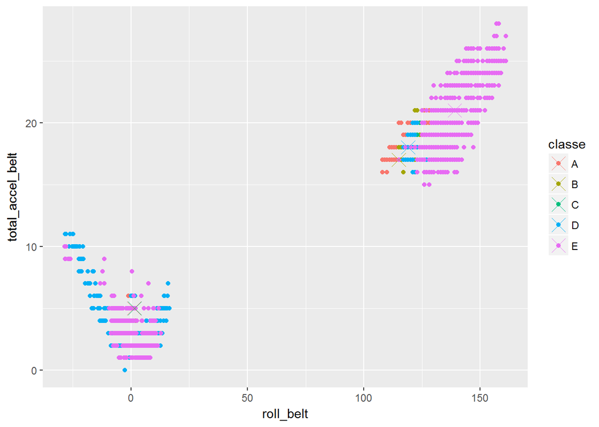

```r
#Setup plot data for roll(belt,arm,dumbbell,forearm)
plot_data_1<-classCenter(validation_set[,c(1,4)],validation_set$classe,mod_fit_rf_out$finalModel$proximity)
plot_data_1<-as.data.frame(plot_data_1)
plot_data_1$classe<-rownames(plot_data_1)

#plot_data_2<-classCenter(validation_set[,c(5,8)],validation_set$classe,mod_fit_rf_out$finalModel$proximity)
#plot_data_2<-as.data.frame(plot_data_2)
#plot_data_2$classe<-rownames(plot_data_2)

#plot_data_3<-classCenter(validation_set[,c(9,12)],validation_set$classe,mod_fit_rf_out$finalModel$proximity)
#plot_data_3<-as.data.frame(plot_data_3)
#plot_data_3$classe<-rownames(plot_data_3)

#plot_data_4<-classCenter(validation_set[,c(13,16)],validation_set$classe,mod_fit_rf_out$finalModel$proximity)
#plot_data_4<-as.data.frame(plot_data_4)
#plot_data_4$classe<-rownames(plot_data_4)

#Plot for roll(belt,arm,dumbbell,forearm) by total acceleration per classe
par(mfrow=c(4,1))
plot_1<-qplot(roll_belt,total_accel_belt,col=classe,data=validation_set)
plot_1+geom_point(aes(x=roll_belt,y=total_accel_belt,col=classe),size=5,shape=4,data=plot_data_1)
```

```r
#plot_2<-qplot(roll_arm,total_accel_arm,col=classe,data=validation_set)
#plot_2+geom_point(aes(x=roll_arm,y=total_accel_arm,col=classe),size=5,shape=4,data=plot_data_2)

#plot_3<-qplot(roll_dumbbell,total_accel_dumbbell,col=classe,data=validation_set)
#plot_3+geom_point(aes(x=roll_dumbbell,y=total_accel_dumbbell,col=classe),size=5,shape=4,data=plot_data_3)

#plot_4<-qplot(roll_forearm,total_accel_forearm,col=classe,data=validation_set)
#$plot_4+geom_point(aes(x=roll_forearm,y=total_accel_forearm,col=classe),size=5,shape=4,data=plot_data_4)
```

# Prediction Model Section

1. Test run on validation data set yielded 100% accuracy

```r
pred<-predict(mod_fit_rf_out,validation_set)
validation_set$predRight<-pred==validation_set$classe
table(pred,validation_set$classe)
```

```
##
## pred    A    B    C    D    E
##    A 1674    0    0    0    0
##    B    0 1139    0    0    0
##    C    0    0 1026    0    0
##    D    0    0    0  964    0
##    E    0    0    0    0 1082
```

```r
cmatrix_rf<-confusionMatrix(pred,validation_set$classe)
AccuracyResults<-data.frame(Model=c('Random Forest'),Accuracy=rbind(cmatrix_rf$overall[1]))
print(AccuracyResults)
```

```
##           Model Accuracy
## 1 Random Forest        1
```

```r
pred_test<-predict(mod_fit_rf_out,testing_nona)
results<-data.frame(problem_id=testing_nona$problem_id,predicted=pred_test)
testing_nona$classe<-pred_test
#print(results)

testing_nona$predRight<-pred_test==testing_nona$classe
table(pred_test,testing_nona$classe)
```

```
##
## pred_test A B C D E
##         A 9 0 0 0 0
##         B 0 6 0 0 0
##         C 0 0 1 0 0
##         D 0 0 0 1 0
##         E 0 0 0 0 3
```

```r
cmatrix_rf<-confusionMatrix(pred_test,testing_nona$classe)
AccuracyResults<-data.frame(Model=c('Random Forest'),Accuracy=rbind(cmatrix_rf$overall[1]))
print(AccuracyResults)
```

```
##           Model Accuracy
## 1 Random Forest        1
```